# Final Project

## Linear Regression

```r
model1 <- lm(popularity ~ acousticness + danceability + duration_ms + energy
             + explicit + instrumentalness + key + liveness + loudness
             + speechiness + tempo + tempo + valence +mode + decade,
             data = sdata )

summary(model1)
```

```
##
## Call:
## lm(formula = popularity ~ acousticness + danceability + duration_ms +
##     energy + explicit + instrumentalness + key + liveness + loudness +
##     speechiness + tempo + tempo + valence + mode + decade, data = sdata)
##
## Residuals:
##     Min      1Q  Median      3Q     Max
## -56.438  -8.638  -1.205   7.255  78.121
##
## Coefficients:
##                    Estimate Std. Error t value Pr(>|t|)
## (Intercept)       1.796e+01  4.478e-01  40.106  < 2e-16 ***
## acousticness     -9.807e-01  1.733e-01  -5.660 1.51e-08 ***
## danceability      2.164e+00  2.871e-01   7.538 4.79e-14 ***
## duration_ms      -4.222e-06  2.577e-07 -16.382  < 2e-16 ***
## energy           -7.805e+00  3.052e-01 -25.575  < 2e-16 ***
## explicit1         1.219e+01  1.652e-01  73.752  < 2e-16 ***
## instrumentalness -9.134e+00  1.286e-01 -71.003  < 2e-16 ***
## key              -3.865e-02  1.055e-02  -3.664 0.000248 ***
## liveness         -6.628e+00  2.136e-01 -31.038  < 2e-16 ***
## loudness          3.951e-01  1.189e-02  33.238  < 2e-16 ***
## speechiness      -1.096e+01  2.628e-01 -41.689  < 2e-16 ***
## tempo            -4.377e-03  1.283e-03  -3.411 0.000647 ***
## valence          -1.325e+00  1.955e-01  -6.777 1.23e-11 ***
## mode1            -2.609e-01  8.198e-02  -3.182 0.001462 **
## decade1930        7.567e-01  2.537e-01   2.983 0.002856 **
## decade1940       -2.207e-01  2.420e-01  -0.912 0.361959
## decade1950        7.727e+00  2.374e-01  32.547  < 2e-16 ***
## decade1960        2.222e+01  2.430e-01  91.454  < 2e-16 ***
## decade1970        3.040e+01  2.488e-01 122.193  < 2e-16 ***
## decade1980        3.280e+01  2.528e-01 129.748  < 2e-16 ***
## decade1990        3.735e+01  2.505e-01 149.109  < 2e-16 ***
## decade2000        3.707e+01  2.640e-01 140.420  < 2e-16 ***
## decade2010        2.407e+01  2.537e-01  94.891  < 2e-16 ***
## decade2020        1.418e+01  3.027e-01  46.835  < 2e-16 ***
## ---
## Signif. codes:  0 '***' 0.001 '**' 0.01 '*' 0.05 '.' 0.1 ' ' 1
##
## Residual standard error: 15.36 on 174365 degrees of freedom
## Multiple R-squared:  0.5071, Adjusted R-squared:  0.5071
## F-statistic:  7800 on 23 and 174365 DF,  p-value: < 2.2e-16
```

### Assessing Regression

```r
set.seed(12345)
testset = sample(1:nrow(sdata), 0.2*nrow(sdata))
sdata_test = sdata[testset, ]
sdata_train = sdata[-testset, ]
```

## Linear Regression Using Train / Test Split

```r
model1_train <- lm(popularity ~ acousticness + danceability + duration_ms + energy
             + explicit + instrumentalness + key + liveness + loudness
             + speechiness + tempo + tempo + valence +mode + decade,
             data = sdata_train )

summary(model1_train)
```

```
##
## Call:
## lm(formula = popularity ~ acousticness + danceability + duration_ms +
##     energy + explicit + instrumentalness + key + liveness + loudness +
##     speechiness + tempo + tempo + valence + mode + decade, data = sdata_train)
##
## Residuals:
##     Min      1Q  Median      3Q     Max
## -56.511  -8.691  -1.210   7.290  78.163
##
## Coefficients:
##                    Estimate Std. Error t value Pr(>|t|)
## (Intercept)       1.810e+01  5.020e-01  36.057  < 2e-16 ***
## acousticness     -9.942e-01  1.940e-01  -5.125 2.97e-07 ***
## danceability      2.348e+00  3.216e-01   7.302 2.86e-13 ***
## duration_ms      -4.252e-06  2.904e-07 -14.641  < 2e-16 ***
## energy           -7.909e+00  3.420e-01 -23.127  < 2e-16 ***
## explicit1         1.224e+01  1.853e-01  66.018  < 2e-16 ***
## instrumentalness -9.140e+00  1.441e-01 -63.419  < 2e-16 ***
## key              -4.343e-02  1.181e-02  -3.677 0.000236 ***
## liveness         -6.683e+00  2.394e-01 -27.918  < 2e-16 ***
## loudness          4.037e-01  1.334e-02  30.259  < 2e-16 ***
## speechiness      -1.100e+01  2.945e-01 -37.339  < 2e-16 ***
## tempo            -4.310e-03  1.437e-03  -3.000 0.002698 **
## valence          -1.338e+00  2.190e-01  -6.111 9.90e-10 ***
## mode1            -2.897e-01  9.174e-02  -3.158 0.001589 **
## decade1930        7.493e-01  2.842e-01   2.637 0.008364 **
## decade1940       -2.003e-01  2.713e-01  -0.738 0.460440
## decade1950        7.765e+00  2.656e-01  29.232  < 2e-16 ***
## decade1960        2.218e+01  2.720e-01  81.540  < 2e-16 ***
## decade1970        3.040e+01  2.784e-01 109.190  < 2e-16 ***
## decade1980        3.284e+01  2.828e-01 116.138  < 2e-16 ***
## decade1990        3.724e+01  2.802e-01 132.892  < 2e-16 ***
## decade2000        3.703e+01  2.956e-01 125.269  < 2e-16 ***
## decade2010        2.402e+01  2.838e-01  84.649  < 2e-16 ***
## decade2020        1.417e+01  3.383e-01  41.895  < 2e-16 ***
## ---
## Signif. codes:  0 '***' 0.001 '**' 0.01 '*' 0.05 '.' 0.1 ' ' 1
##
## Residual standard error: 15.38 on 139488 degrees of freedom
## Multiple R-squared:  0.5056, Adjusted R-squared:  0.5055
## F-statistic:  6202 on 23 and 139488 DF,  p-value: < 2.2e-16
```

```r
popular_predict = predict(model1_train, sdata_test)

cor(popular_predict, sdata_test$popularity)
```

```
## [1] 0.7163621
```

> As shown above, when assessing the linear regression model on training and test data - the model performs well with .72 correlation between predicted popularity and actual popularity in the test data

## ANN Model

> To prep the data for ANN, we first removed the variables that are unneccesary such as the track ID and song name. To avoid our model from being skewed by the scale of variables we normalized the data after converting all variables into numeric data using model matrix. Given the high number of observations, we also chose to run the ANN on a randomized subset of the original dataset to reduce runtime.

```r
library(neuralnet)
normalize <- function(x) {
  return((x - min(x)) / (max(x) - min(x)))
}

spotify_draft = sdata
str(spotify_draft)
```

```
## 'data.frame':    174389 obs. of  20 variables:
##  $ acousticness    : num  0.991 0.643 0.993 0.000173 0.295 0.996 0.992 0.996 0.996 0.00682 ...
##  $ artists         : chr  "['Mamie Smith']" "[\"Screamin' Jay Hawkins\"]" "['Mamie Smith']" "['Oscar Velazquez']" ...
##  $ danceability    : num  0.598 0.852 0.647 0.73 0.704 0.424 0.782 0.474 0.469 0.571 ...
##  $ duration_ms     : int  168333 150200 163827 422087 165224 198627 195200 186173 146840 476304 ...
##  $ energy          : num  0.224 0.517 0.186 0.798 0.707 0.245 0.0573 0.239 0.238 0.753 ...
##  $ explicit        : Factor w/ 2 levels "0","1": 1 1 1 1 2 1 1 1 1 1 ...
##  $ id              : chr  "0cS0A1fUEUd1EW3FcF8AEI" "0hbkKFIJm7Z05H8Zl9w30f" "11m7laMUgmOKqI3oYzuhne" "19Lc5SfJJ5O1oaxY0fpwfh" ...
##  $ instrumentalness: num  5.22e-04 2.64e-02 1.76e-05 8.01e-01 2.46e-04 7.99e-01 1.61e-06 1.86e-01 9.60e-01 8.73e-01 ...
##  $ key             : int  5 5 0 2 10 5 5 9 8 8 ...
##  $ liveness        : num  0.379 0.0809 0.519 0.128 0.402 0.235 0.176 0.195 0.149 0.092 ...
##  $ loudness        : num  -12.63 -7.26 -12.1 -7.31 -6.04 ...
##  $ mode            : Factor w/ 2 levels "0","1": 1 1 2 2 1 2 2 2 2 2 ...
##  $ name            : chr  "Keep A Song In Your Soul" "I Put A Spell On You" "Golfing Papa" "True House Music - Xavier Santos & Carlos Gomix Remix" ...
##  $ popularity      : int  12 7 4 17 2 9 5 0 0 0 ...
##  $ release_date    : chr  "1920" "1920-01-05" "1920" "1920-01-01" ...
##  $ speechiness     : num  0.0936 0.0534 0.174 0.0425 0.0768 0.0397 0.0592 0.0289 0.0741 0.0446 ...
##  $ tempo           : num  150 86.9 97.6 128 122.1 ...
##  $ valence         : num  0.634 0.95 0.689 0.0422 0.299 0.477 0.487 0.366 0.621 0.119 ...
##  $ year            : int  1920 1920 1920 1920 1920 1920 1920 1920 1920 1920 ...
##  $ decade          : Factor w/ 11 levels "1920","1930",..: 1 1 1 1 1 1 1 1 1 1 ...
```

```r
spotify_draft$artists = NULL
spotify_draft$id = NULL
spotify_draft$name = NULL
spotify_draft$release_date = NULL
spotify_draft$year = NULL

str(spotify_draft)
```

```
## 'data.frame':    174389 obs. of  15 variables:
##  $ acousticness    : num  0.991 0.643 0.993 0.000173 0.295 0.996 0.992 0.996 0.996 0.00682 ...
##  $ danceability    : num  0.598 0.852 0.647 0.73 0.704 0.424 0.782 0.474 0.469 0.571 ...
##  $ duration_ms     : int  168333 150200 163827 422087 165224 198627 195200 186173 146840 476304 ...
##  $ energy          : num  0.224 0.517 0.186 0.798 0.707 0.245 0.0573 0.239 0.238 0.753 ...
##  $ explicit        : Factor w/ 2 levels "0","1": 1 1 1 1 2 1 1 1 1 1 ...
##  $ instrumentalness: num  5.22e-04 2.64e-02 1.76e-05 8.01e-01 2.46e-04 7.99e-01 1.61e-06 1.86e-01 9.60e-01 8.73e-01 ...
##  $ key             : int  5 5 0 2 10 5 5 9 8 8 ...
##  $ liveness        : num  0.379 0.0809 0.519 0.128 0.402 0.235 0.176 0.195 0.149 0.092 ...
##  $ loudness        : num  -12.63 -7.26 -12.1 -7.31 -6.04 ...
##  $ mode            : Factor w/ 2 levels "0","1": 1 1 2 2 1 2 2 2 2 2 ...
##  $ popularity      : int  12 7 4 17 2 9 5 0 0 0 ...
##  $ speechiness     : num  0.0936 0.0534 0.174 0.0425 0.0768 0.0397 0.0592 0.0289 0.0741 0.0446 ...
##  $ tempo           : num  150 86.9 97.6 128 122.1 ...
##  $ valence         : num  0.634 0.95 0.689 0.0422 0.299 0.477 0.487 0.366 0.621 0.119 ...
##  $ decade          : Factor w/ 11 levels "1920","1930",..: 1 1 1 1 1 1 1 1 1 1 ...
```

```r
spotify_mmatrix <- as.data.frame(model.matrix(~. - 1,spotify_draft))


spotify_norm <- as.data.frame(lapply(spotify_mmatrix, normalize))

set.seed(12345)
testset = sample(1:nrow(spotify_norm), 0.2*nrow(spotify_norm))
spotify_norm_test = spotify_norm[testset, ]
spotify_norm_train = spotify_norm[-testset, ]

str(spotify_norm_train)
```

```
## 'data.frame':    139512 obs. of  25 variables:
##  $ acousticness    : num  0.645582 0.996988 0.000174 0.296185 1 ...
##  $ danceability    : num  0.862 0.655 0.739 0.713 0.429 ...
##  $ duration_ms     : num  0.0272 0.0298 0.0782 0.0301 0.0363 ...
##  $ energy          : num  0.517 0.186 0.798 0.707 0.245 0.0573 0.239 0.238 0.753 0.22 ...
##  $ explicit0       : num  1 1 1 0 1 1 1 1 1 1 ...
##  $ explicit1       : num  0 0 0 1 0 0 0 0 0 0 ...
##  $ instrumentalness: num  2.64e-02 1.76e-05 8.01e-01 2.46e-04 7.99e-01 1.61e-06 1.86e-01 9.60e-01 8.73e-01 0.00 ...
##  $ key             : num  0.455 0 0.182 0.909 0.455 ...
##  $ liveness        : num  0.0809 0.519 0.128 0.402 0.235 0.176 0.195 0.149 0.092 0.262 ...
##  $ loudness        : num  0.826 0.75 0.825 0.845 0.76 ...
##  $ mode1           : num  0 1 1 0 1 1 1 1 1 0 ...
##  $ popularity      : num  0.07 0.04 0.17 0.02 0.09 0.05 0 0 0 0 ...
##  $ speechiness     : num  0.055 0.1792 0.0438 0.0791 0.0409 ...
##  $ tempo           : num  0.357 0.401 0.526 0.501 0.427 ...
##  $ valence         : num  0.95 0.689 0.0422 0.299 0.477 0.487 0.366 0.621 0.119 0.414 ...
##  $ decade1930      : num  0 0 0 0 0 0 0 0 0 0 ...
##  $ decade1940      : num  0 0 0 0 0 0 0 0 0 0 ...
##  $ decade1950      : num  0 0 0 0 0 0 0 0 0 0 ...
##  $ decade1960      : num  0 0 0 0 0 0 0 0 0 0 ...
##  $ decade1970      : num  0 0 0 0 0 0 0 0 0 0 ...
##  $ decade1980      : num  0 0 0 0 0 0 0 0 0 0 ...
##  $ decade1990      : num  0 0 0 0 0 0 0 0 0 0 ...
##  $ decade2000      : num  0 0 0 0 0 0 0 0 0 0 ...
##  $ decade2010      : num  0 0 0 0 0 0 0 0 0 0 ...
##  $ decade2020      : num  0 0 0 0 0 0 0 0 0 0 ...
```

```r
ann_model <- neuralnet(formula = popularity ~ ., data = spotify_norm_train[1:17000, ])
plot(ann_model)

# obtain model results
model_results <- compute(ann_model, spotify_norm_test[1:17000, ])
# obtain predicted strength values
predicted_pop <- model_results$net.result
# examine the correlation between predicted and actual values
cor(predicted_pop, spotify_norm_test$popularity[1:17000])
```

```
##           [,1]
## [1,] 0.6945617
```

> Running the ANN on a subset of the randomized test and train data, we can see that our ANN prediction results have a correlation coefficient of .69 when compared to the test data. This correlation is slighly less than our results from the linear regression.

# Modeling of Popularity as a Categorical Outcome Variable

## Logistic Regression

> In the original dataset, popularity is a continuous variable from 0-100. However, we also wanted to assess popularity in a binary, categorical sense: is the song popular, or is it not? To do so, we created a new factor outcome variable, popularity2, which is a 1 if popularity is greater than 42 and is 0 if popularity is less than 42. 42 was selected as the cutoff since it is the third quartile of popularity.

#### Data Cleaning and Manipulation

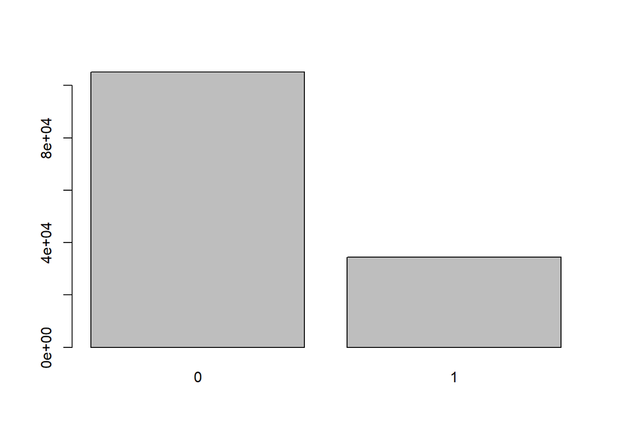

```r
sdata_test$popularity2 = as.factor(ifelse(sdata_test$popularity>42,1,0))
sdata_train$popularity2 = as.factor(ifelse(sdata_train$popularity>42,1,0))

plot(sdata_train$popularity2)
```

```r
log_model1= glm(popularity2 ~  acousticness + danceability + duration_ms + energy + explicit + instrumentalness + key + liveness + loudness + speechiness + tempo + valence +decade ,data = sdata_train, family = "binomial")

summary(log_model1)
```

```
##
## Call:
## glm(formula = popularity2 ~ acousticness + danceability + duration_ms +
##     energy + explicit + instrumentalness + key + liveness + loudness +
##     speechiness + tempo + valence + decade, family = "binomial",
##     data = sdata_train)
##
## Deviance Residuals:
##     Min       1Q   Median       3Q      Max
## -2.4461  -0.6877  -0.2413  -0.0218   4.0163
##
## Coefficients:
##                    Estimate Std. Error z value Pr(>|z|)
## (Intercept)      -4.538e+00  5.070e-01  -8.952  < 2e-16 ***
## acousticness     -1.036e-01  3.526e-02  -2.938   0.0033 **
## danceability      4.714e-01  5.728e-02   8.229  < 2e-16 ***
## duration_ms      -3.960e-07  6.668e-08  -5.939 2.86e-09 ***
## energy           -1.207e+00  6.329e-02 -19.066  < 2e-16 ***
## explicit1         1.098e+00  3.196e-02  34.350  < 2e-16 ***
## instrumentalness -1.425e+00  3.297e-02 -43.207  < 2e-16 ***
## key              -4.535e-03  2.130e-03  -2.129   0.0333 *
## liveness         -9.757e-01  4.575e-02 -21.325  < 2e-16 ***
## loudness          8.182e-02  2.907e-03  28.148  < 2e-16 ***
## speechiness      -1.670e+00  9.948e-02 -16.789  < 2e-16 ***
## tempo            -4.134e-04  2.708e-04  -1.527   0.1269
## valence          -2.637e-01  3.923e-02  -6.723 1.79e-11 ***
## decade1930        7.438e-01  5.532e-01   1.345   0.1787
## decade1940        1.248e+00  5.232e-01   2.386   0.0170 *
## decade1950        3.048e+00  5.030e-01   6.060 1.36e-09 ***
## decade1960        4.522e+00  5.012e-01   9.022  < 2e-16 ***
## decade1970        5.308e+00  5.010e-01  10.595  < 2e-16 ***
## decade1980        5.639e+00  5.010e-01  11.255  < 2e-16 ***
## decade1990        6.394e+00  5.009e-01  12.766  < 2e-16 ***
## decade2000        7.480e+00  5.011e-01  14.926  < 2e-16 ***
## decade2010        6.227e+00  5.009e-01  12.431  < 2e-16 ***
## decade2020        5.016e+00  5.021e-01   9.990  < 2e-16 ***
## ---
## Signif. codes:  0 '***' 0.001 '**' 0.01 '*' 0.05 '.' 0.1 ' ' 1
##
## (Dispersion parameter for binomial family taken to be 1)
##
##     Null deviance: 155736  on 139511  degrees of freedom
## Residual deviance: 107870  on 139489  degrees of freedom
## AIC: 107916
##
## Number of Fisher Scoring iterations: 9
```

#### Predicting and classification logistic regression

```r
log1_predict = predict(log_model1, sdata_test)
log1_predict = ifelse(log1_predict > 0.1, 1, 0)
log1_predict = as.factor(log1_predict)

library(caret)
confusionMatrix(log1_predict, sdata_test$popularity2)
```

```
## Confusion Matrix and Statistics
##
##           Reference
## Prediction     0     1
##          0 24652  4664
##          1  1661  3900
##
##                Accuracy : 0.8186
##                  95% CI : (0.8146, 0.8227)
##     No Information Rate : 0.7545
##     P-Value [Acc > NIR] : < 2.2e-16
##
##                   Kappa : 0.4449
##
##  Mcnemar's Test P-Value : < 2.2e-16
##
##             Sensitivity : 0.9369
##             Specificity : 0.4554
##          Pos Pred Value : 0.8409
##          Neg Pred Value : 0.7013
##              Prevalence : 0.7545
##          Detection Rate : 0.7068
##    Detection Prevalence : 0.8406
##       Balanced Accuracy : 0.6961
##
##        'Positive' Class : 0
##
```

## KNN

> Like our ANN analysis, we ran KNN on a randomized subset of the original dataset due to the dataset’s size and associated runtime.

```r
library(class)

spotify_norm_train$popularity = as.factor(ifelse(spotify_norm_train$popularity>.42,1,0))
spotify_norm_test$popularity = as.factor(ifelse(spotify_norm_test$popularity>.42,1,0))

spotify_norm_train_x = spotify_norm_train[,-12]
spotify_norm_train_y = spotify_norm_train[,12]

spotify_norm_test_x = spotify_norm_test[,-12]
spotify_norm_test_y = spotify_norm_test[,12]


#K determined based on square root of the number of observations in the train set
KNN_model <- knn(train = spotify_norm_train_x[1:17000,], test = spotify_norm_test_x[1:17000,],
                      cl = spotify_norm_train_y[1:17000], k= round(sqrt(nrow(spotify_norm_train_x[1:17000,]))))

library(gmodels)
#Confusion matrix
CrossTable(x = spotify_norm_test_y[1:17000], y = KNN_model,
           prop.chisq=FALSE)
```

```
##
##
##    Cell Contents
## |-------------------------|
## |                       N |
## |           N / Row Total |
## |           N / Col Total |
## |         N / Table Total |
## |-------------------------|
##
##
## Total Observations in Table:  17000
##
##
##                              | KNN_model
## spotify_norm_test_y[1:17000] |         0 |         1 | Row Total |
## -----------------------------|-----------|-----------|-----------|
##                            0 |      6407 |      6435 |     12842 |
##                              |     0.499 |     0.501 |     0.755 |
##                              |     0.933 |     0.635 |           |
##                              |     0.377 |     0.379 |           |
## -----------------------------|-----------|-----------|-----------|
##                            1 |       462 |      3696 |      4158 |
##                              |     0.111 |     0.889 |     0.245 |
##                              |     0.067 |     0.365 |           |
##                              |     0.027 |     0.217 |           |
## -----------------------------|-----------|-----------|-----------|
##                 Column Total |      6869 |     10131 |     17000 |
##                              |     0.404 |     0.596 |           |
## -----------------------------|-----------|-----------|-----------|
##
##
```

```r
library(caret)

confusionMatrix(spotify_norm_test_y[1:17000], KNN_model)
```

```
## Confusion Matrix and Statistics
##
##           Reference
## Prediction    0    1
##          0 6407 6435
##          1  462 3696
##
##                Accuracy : 0.5943
##                  95% CI : (0.5869, 0.6017)
##     No Information Rate : 0.5959
##     P-Value [Acc > NIR] : 0.6721
##
##                   Kappa : 0.261
##
##  Mcnemar's Test P-Value : <2e-16
##
##             Sensitivity : 0.9327
##             Specificity : 0.3648
##          Pos Pred Value : 0.4989
##          Neg Pred Value : 0.8889
##              Prevalence : 0.4041
##          Detection Rate : 0.3769
##    Detection Prevalence : 0.7554
##       Balanced Accuracy : 0.6488
##
##        'Positive' Class : 0
##
```

> Our KNN model has a Kappa Statistic of .2615, indicating worse overall performance than the logistic regression. However, the KNN model results in far fewer false negatives, indicating we may be able to predict more hit songs. If the investment in songs is minimal and the payout in hits is significant, this may be a better method for prediction.

## Conclusion and Discussion of Results

> In both cases of analyzing song popularity - either a continuous or categorical output variable - the simpler model performs better when analyzing results.

> When analyzing popularity as a binary categorical variable, we introduced two levels of subjectivity that in future use would need to be constantly justified: the cutoff of what constitues “popular” (in our case, we decided on a level 42 popularity which is the third quartile) and the prediction odds threshold that would consititute popularity when predicting results for logistic regression (we chose 0.1 given the skewness of the data). While the logistic regression with these parameters performed better than the KNN, the KNN was subject to only one of these subjective parameters, which may lend itself to a more objective estimation. In that vein, KNN also had much fewer false negatives, which may impact potential financial return of hit songs are missed.